# Automated identification of malaria cells in microscopy images - Part 1

# Table of Contents

## Abbreviations

COCO - common objects in context

CNN - convolutional neural network

DETR - detection transformer

GIoU - generalised intersection over union

RBC - red blood cell

RDT - rapid diagnostic test

## Introduction

### Malaria

Malaria is an infectious disease that is transmitted through the bites of female *Anopheles* mosquitoes infected with the parasite *Plasmodium*. Despite being a treatable disease, nearly 400,000 people died of malaria in the year 2020. 94% of these deaths occured in Sub-Saharan Africa, where cases often go undetected due to the lack of testing facilities. According to the World Health Organisation, testing is crucial to the control of malaria as it allows the incidence of the disease to be studied on a national and regional level. This information is needed to direct resources to where they are needed most, assess the impact of existing programmes and plan effective responses to future outbreaks.

### Diagnosis

Currently, the gold standard for malaria diagnosis is microscopic examination of patient's blood samples. In addition to detecting the presence of *Plasmodium* infected red blood cells, a skilled laboratorian can also identify the stage of infection and the species of Plasmodium, which are key factors in determining the course of treatment. However, the presence of artefacts in blood smears as well as variations in cellular morphology can make diagnosis extremely challenging. Furthermore, rural hospitals in Sub-Saharan Africa, where malaria is most prevalent, often lack the trained professionals required to perform these tests.

Malaria can also be tested for by using a rapid diagnostic test (RDT), which is simpler to use. However, these tests are expensive, have variable sensitivity and, unlike microscopic examination, cannot distinguish between different species of *Plasmodium* or quantify the number of infected cells. Although RDTs are useful in diagnosing and monitoring malaria, especially in rural areas that lack specialist laboratories, RDT's do not eliminate the need for microscopic examination.

[figure not shown]

(*Plasmodium falciparum* mortality rate per 100,000 people across Africa and South Asia in 2019.)

## Aim

### Motivation

Currently, regions that do not have the facilities to perform microscopic examination must instead rely on RDTs, which are expensive and often inaccurate. Automating the detection and classification of infected cells from microscopy images will widen the availability of fast and reliable malaria testing, especially in rural and impoverished areas. Wider testing will enable better surveillance of malaria cases and, consequently, more effective control of the disease. In addition, this model could be adapted to diagnose a wide range of fungal and parasitic diseases that are traditionally diagnosed by microscopic examination such as sleeping sickness, lymphatic filariasis and babesiosis.

### Dataset

The aim of this study was to automate the labour intensive process of microscopic examination for the diagnosis of malaria. For this task, we used dataset BBBC041v1 from the Broad Bioimage Benchmark Collection (BBBC), which contains images of blood smears taken from individuals infected with *Plasmodium vivax*. The images were manually annotated with bounding boxes and class labels for each cell. Uninfected red blood cells and leukocytes were labelled as such whilst infected red blood cells (RBCs) were labelled according to the parasite's stage of development; gametocyte, ring, trophozoite or schizont.

### Methodology

Previously, a two step approach has been used to detect and classify infected cells in the BBBC041v1 dataset. First, a Faster Region-based Convolutional Neural Network (Faster R-CNN) was used detect individual cells and distinguish uninfected RBCs from infected cells. Infected cells were further classified into gametocytes, rings, trophozoites and schizonts using a conventional CNN such as Alex-Net. In this study, I adopt a similar approach and fine-tune a pre-trained Detection Tansformer (DETR) model to detect cells and a custom CNN to classify them.

DETR is a model, released by Facebook AI research in 2020, that repurposes the transformer encoder decoder architecture to solve an object detection task. Transformers were originally designed to solve natural language processing tasks but, as DETR has demonstrated, they are also uniquely suited to object detection tasks. This is because the encoder of the transformer uses an attention mechanism that is able to learn long-range dependencies between different regions of images, which is useful since bounding boxes span many pixels in an image.

Another reason for using DETR is that, compared to current state-of-the-art object-detection models, DETR uses a much simple architecture. It has fewer hyperparameters and does not require *a-priori* information about objects, such as anchors or aspect ratios, to be inputted prior to training. This makes it much simpler to fine-tune DETR on a custom dataset compared to other pre-trained models.

## Import libraries

```python
import malaria_helper # custom functions and classes for data visualisation and model predictions
from malaria_helper import cells_image

import numpy as np
import pandas as pd
import json
from PIL import Image
import matplotlib.pyplot as plt
from matplotlib.lines import Line2D

import os
import time
from tqdm.autonotebook import tqdm

import torch
import torchvision
import torch.nn as nn
from torch.utils.data import DataLoader
from torch.utils.tensorboard import SummaryWriter
import sys

sys.path.append('./detr/')
from transformers import DetrFeatureExtractor
from detr.models.matcher import HungarianMatcher
from detr.models.detr import SetCriterion

pd.options.display.max_columns = 100
```

## Data exploration

```python
with open('training.json') as f1, open('test.json') as f2:
    train = json.load(f1)
    test = json.load(f2)

print('No. of images in train: ' + str(len(train)))
print('No. of images in test: ' + str(len(test)))
```

```
No. of images in train: 1208
No. of images in test: 120
```

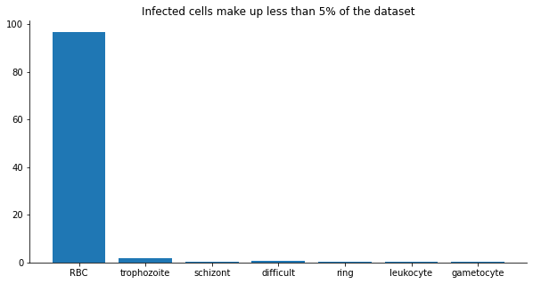

```python
malaria_helper.plot_class_counts(train)
```

Plotting two images from the training dataset shows that there is significant overlap between cells and the slide contains several artefacts out-of-focus cells. Therefore, the model will need to learn to detect individual cells in crowded regions and avoid any artefacts or cells that are out of focus.

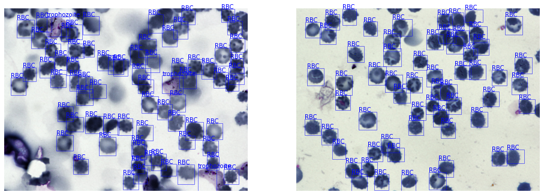

```python
fig, (ax1, ax2) = plt.subplots(nrows=1, ncols=2,figsize = (16,10))

cells1 = cells_image(number = 0, json_name = train, axis=ax1)
cells2 = cells_image(number = 1, json_name = train, axis=ax2)

# Plot blood smear image
cells1.plot_cells()
cells2.plot_cells()
# Plot ground truth bounding boxes and class labels for each cell
cells1.plot_ground()
cells2.plot_ground()
```

## Create COCO annotation file

In order to convert the class label and bounding box information in the json files into the format that DETR requires, I used the `DetrFeatureExtractor` module from the `Transformers` library. Since this module takes in a COCO-style annotation file, the annotations in the json files were first converted to the COCO format.

```python
def COCOann(dataset, path, encoder):
    '''
    This function uses the information in a Pandas DataFrame to create a COCO-style annotation file with three
    sections; CATEGORIES, IMAGES and ANNOTATIONS.
    '''
    bbox = np.empty((dataset.shape[0], 6))
    paths = []
    labels = []

    # Iterate through dataframe and extract bounding box and class label information
    for i, row in dataset.iterrows():
        x_min = row['objects']['bounding_box']['minimum']['c']
        y_min = row['objects']['bounding_box']['minimum']['r']
        x_max = row['objects']['bounding_box']['maximum']['c']
        y_max = row['objects']['bounding_box']['maximum']['r']
        width = x_max - x_min
        height = y_max - y_min
        image_width = row['image']['shape']['c']
        image_height = row['image']['shape']['r']
        coordinates = [x_min,y_min,width,height,image_width, image_height]
        bbox[i] = coordinates
        paths.append(row['image']['pathname'])
        labels.append(row['objects']['category'])

    for i, column in enumerate(['x_min', 'y_min', 'width', 'height', 'image_width', 'image_height']):
        dataset[column] = bbox[:,i]

    dataset['pathname'] = paths
    dataset['category'] = labels
    category_dict = {'red blood cell':1, 'trophozoite':2, 'schizont' :2, 'difficult':2, 'ring':2,
       'leukocyte':2, 'gametocyte':2}
    dataset['category_id'] = dataset['category'].map(category_dict)

    dataset = dataset.drop(['image','objects'], axis=1)
    dataset.columns = ['ann_id', 'image_id', 'x_min', 'y_min', 'width', 'height', 'image_width', 'image_height',
                        'pathname', 'category','category_id']

    # CATEGORIES section - maps class IDs to name of cell. Only two categories RBC and other.
    CATEGORIES = [
    {   'id': 1,
        'name': 'red blood cell',
        'supercategory': 'RBC',
    },
    {   'id': 2,
        'name': 'other',
        'supercategory': 'notRBC',
    },]

    # IMAGES section of COCO annotation file - contains image ID and file path to image.
    IMAGES = []

    for index, row in enumerate(dataset['pathname'].unique()):
        my_dict = {'height':1200, 'width':1600}
        my_dict['id'] = dataset[dataset['pathname'] == row].iloc[0]['image_id']
        my_dict['file_name'] = row[8:]
        IMAGES.append(my_dict)

    # ANNOTATIONS section of COCO annotation file - contains bounding box and class label for each cell in image.
    ANNOTATIONS = []

    for index, row in dataset.iterrows():
        my_dict = {}
        my_dict['area'] = row['width']*row['height']
        my_dict['bbox'] = [row['x_min'], row['y_min'], row['width'], row['height']]
        my_dict['image_id'] = row['image_id']
        my_dict['category_id'] = row['category_id']
        my_dict['id'] = row['ann_id']
        ANNOTATIONS.append(my_dict)

    data_coco = {}
    data_coco['images'] = IMAGES
    data_coco['categories'] = CATEGORIES
    data_coco['annotations'] = ANNOTATIONS
    # Save COCO annotation file in same directory as notebook.
    json.dump(data_coco, open(path, "w"), indent=4, cls=encoder)

    return

class NpEncoder(json.JSONEncoder):
    def default(self, obj):
        if isinstance(obj, np.integer):
            return int(obj)
        if isinstance(obj, np.floating):
            return float(obj)
        if isinstance(obj, np.ndarray):
            return obj.tolist()
        return super(NpEncoder, self).default(obj)
```

```python
# Split the training json file into training and validation datasets and convert to a Pandas DataFrame
train_df = pd.read_json('training.json')
train_df = train_df.explode('objects').reset_index()

train1_df = train_df[train_df['index'] <= 1100].reset_index()
val_df = train_df[train_df['index'] > 1100].reset_index()

test_df = pd.read_json('test.json')
test_df = test_df.explode('objects').reset_index().reset_index()

# Convert Pandas datasets to the COCO annotation file format.
COCOann(train1_df, 'traincoco.json', NpEncoder)
COCOann(val_df, 'valcoco.json', NpEncoder)
COCOann(test_df, 'testcoco.json', NpEncoder)
```

```python
# Save Pandas datasets for later use.
datasets = [train1_df, val_df, test_df]
csvs = ['train1_df.csv', 'val_df.csv', 'test_df.csv']

for i,name in zip(datasets,csvs):
    i = i.drop(['image','objects'],axis=1)
    i.to_csv(name, index=False)
```

## Create PyTorch dataset

Here, I defined a PyTorch `Dataset` class which inherits from Torchvision's `CocoDetection` and has a custom `__getitem__` method that reads in the images in a COCO annotation file and their corresponding target information (i.e. class labels and bounding boxes for each cell in the image). It then uses the `DetrFeatureExtractor` to convert the target information into the format DETR takes.

```python
class CocoDataset(torchvision.datasets.CocoDetection):
    ''' Args:
    root(string): directory where images are stored.
    annFile(string): Path to COCO annotation file.
    feature_extractor(callable): function that transforms image.
    '''
    def __init__(self, root, annFile, feature_extractor):
        super().__init__(root, annFile)
        self.feature_extractor = feature_extractor

    def __getitem__(self, idx):
        '''
        Read in and transform image from annotation file and return tensor of image and bounding box and class labels.
        '''
        img, target = super().__getitem__(idx)
        image_id = self.ids[idx]
        target = {'image_id': image_id, 'annotations': target}
        encoding = self.feature_extractor(images=img, annotations=target, return_tensors="pt")
        pixel_values = encoding["pixel_values"].squeeze() # remove batch dimension
        target = encoding["labels"][0] # remove batch dimension
        return pixel_values, target
```

```python
feature_extractor = DetrFeatureExtractor.from_pretrained("facebook/detr-resnet-50", pad_and_return_pixel_mask = False)
train_dataset = CocoDataset(root='images', annFile = 'traincoco.json', feature_extractor = feature_extractor )
val_dataset = CocoDataset(root='images', annFile = 'valcoco.json', feature_extractor = feature_extractor )
```

```
loading annotations into memory...
Done (t=0.25s)
creating index...
index created!
loading annotations into memory...
Done (t=0.03s)
creating index...
index created!
```

```python
def collate_fn(batch):
    '''
    DataLoader uses this function to process the tuple returned by the __getitem__ method of the CocoDataset class.
    '''
    pixel_values = [item[0] for item in batch]
    labels = [item[1] for item in batch]
    batch = {}
    batch['pixel_values'] = pixel_values
    batch['labels'] = labels
    return batch

train_dataloader = DataLoader(train_dataset, collate_fn=collate_fn, batch_size=16, shuffle =True)
val_dataloader = DataLoader(val_dataset, collate_fn=collate_fn, batch_size=16)
```

## Customising pre-trained DETR model

### Model description

DETR uses a traditional CNN to collect image features; these features are flattened and inputted into an encoder-decoder transformer, which predicts bounding boxes and class labels. The encoder uses an attention mechanism to learn long range dependencies between different parts of an image, which the decoder uses to simultaneously output a fixed number of predictions. DETR then performs bipartite matching, using the Hungarian algorithm, to match predictions with their corresponding ground truths. Once a matching is found that minimises the matching cost, the loss on the bounding boxes is calculated using a mixture of 'L1' and 'Generalised Intersection over Union' (GIoU) whilst the loss on the class labels is calculated using cross-entropy loss.

### Importing pre-trained model

```python
limit = train1_df.groupby('pathname').count().max()[0]
print(f'Maximum number of cells in an image: {limit}')
```

```
Maximum number of cells in an image: 223
```

```python
class DETRModel(nn.Module):
    def __init__(self,num_classes,num_queries):
        super().__init__()
        self.num_classes = num_classes
        self.num_queries = num_queries
        # Load pre-trained DETR model
        self.model = torch.hub.load('facebookresearch/detr', 'detr_resnet50', pretrained=True)
        self.in_features = self.model.class_embed.in_features
        # Modify classification head to predict only two classes of cells and 250 bounding boxes per image
        self.model.class_embed = nn.Linear(in_features=self.in_features,out_features=self.num_classes)
        self.model.num_queries = self.num_queries

    def forward(self,images):
        return self.model(images)
```

### Training and evaluation functions

```python
def train_fn(dataloader,model,epoch):
    model.train()
    # SetCriterion computes the loss of DETR
    criterion.train()

    for i, batch in enumerate(tqdm(dataloader)):
        pixel_values = torch.stack(batch['pixel_values'])
        labels = [{k: v.to(device) for k, v in t.items()} for t in batch['labels']]
        for lab in labels:
            lab['labels'] = lab.pop('class_labels')

        # Return pred_logits (size = [batch_size, 100, 8]) and pred_boxes
        pred = model(pixel_values)
        loss_dict = criterion(pred, labels)
        weight_dict = criterion.weight_dict
        losses = sum(loss_dict[k] * weight_dict[k] for k in loss_dict.keys() if k in weight_dict)

        # Tensorboard log
        x = i + (epoch*69)
        writer.add_scalar(f"Train/Average", losses, x)
        writer.add_scalar(f"Train/class_error", loss_dict['loss_ce'], x)
        writer.add_scalar(f"Train/bbox", loss_dict['loss_bbox'], x)
        writer.add_scalar(f"Train/GIOU", loss_dict['loss_giou'], x)
        writer.add_scalar(f"Train/cardinality", loss_dict['cardinality_error'], x)

        # Backpropagation
        optimizer.zero_grad()
        losses.backward()
        optimizer.step()
    return

def eval_fn(dataloader, model,epoch):
    model.eval()
    with torch.no_grad():
        for i, batch in enumerate(tqdm(dataloader)):
            pixel_values = torch.stack(batch['pixel_values'])
            labels = [{k: v.to(device) for k, v in t.items()} for t in batch['labels']]
            for lab in labels:
                lab['labels'] = lab.pop('class_labels')

            pred = model(pixel_values)
            loss_dict = criterion(pred, labels)
            weight_dict = criterion.weight_dict
            losses = sum(loss_dict[k] * weight_dict[k] for k in loss_dict.keys() if k in weight_dict)

            # Tensorboard log
            x = i + (epoch*69)
            writer.add_scalar(f"Val/Average", losses, x)
            writer.add_scalar(f"Val/class_error", loss_dict['loss_ce'], x)
            writer.add_scalar(f"Val/bbox", loss_dict['loss_bbox'], x)
            writer.add_scalar(f"Val/GIOU", loss_dict['loss_giou'], x)
            writer.add_scalar(f"Val/cardinality", loss_dict['cardinality_error'], x)
    return
```

## Training

```python
device = 'cuda' if torch.cuda.is_available() else 'cpu'
print('Using {} device'.format(device))
```

```
Using cpu device
```

```python
# Load the TensorBoard notebook extension
%load_ext tensorboard
%tensorboard --logdir=malaria_3
```

```python
writer = SummaryWriter('malaria_3/malaria_exp_3')

# Instantiate DETRModel class
model = DETRModel(num_classes=3, num_queries=250).to(device)
matching_fn = HungarianMatcher() # Hungarian algorithm used for bipartite matching
weight_dict = {'loss_ce': 1, 'loss_bbox': 1 , 'loss_giou': 1}
losses = ['labels', 'boxes', 'cardinality']
optimizer = torch.optim.AdamW(model.parameters(), lr=1e-5, weight_decay=1e-4)

# Import loss function from DETR
criterion = SetCriterion(2, matching_fn, weight_dict, eos_coef =0.2, losses=losses)
criterion = criterion.to(device)
```

```
Using cache found in /Users/anushkathawani/.cache/torch/hub/facebookresearch_detr_master
```

```python
# Train for two epochs
for epoch in range(2):
    train_fn(train_dataloader, model, epoch)
    eval_fn(val_dataloader, model, epoch)
    writer.flush()
    torch.save(model.state_dict(), f'malaria_detr_{epoch}.pth')

writer.close()
```

## Evaluation

Having trained for two epochs, the model can now be evaluated on the test set.

```python
# Load model after training for two epochs
model_epoch1 = DETRModel(num_classes=3, num_queries=250).to(device)
model_epoch1.load_state_dict(torch.load('malaria_detr_1.pth'))
```

```
Using cache found in /Users/anushkathawani/.cache/torch/hub/facebookresearch_detr_master
```

```
<All keys matched successfully>
```

### Test set losses

```python
test_dataset = CocoDataset(root='images', annFile = 'testcoco.json', feature_extractor = feature_extractor)
test_dataloader = DataLoader(test_dataset, collate_fn=collate_fn, batch_size=16)
```

```
loading annotations into memory...
Done (t=0.01s)
creating index...
index created!
```

```python
def eval_test(dataloader, model):
    '''
    Determine the average loss, cross entropy loss, L1 loss and GIoU for each epoch and return the average of
    all these losses over eight epochs.
    '''
    model.eval()
    test_loss = {'Avg.':0, 'CEL':0, 'L1':0, 'GIoU':0}

    with torch.no_grad():
        for i, batch in enumerate(tqdm(dataloader)):
            pixel_values = torch.stack(batch['pixel_values'])
            labels = [{k: v.to(device) for k, v in t.items()} for t in batch['labels']]
            for lab in labels:
                lab['labels'] = lab.pop('class_labels')

            pred = model(pixel_values)
            loss_dict = criterion(pred, labels)
            weight_dict = criterion.weight_dict
            losses = sum(loss_dict[k] * weight_dict[k] for k in loss_dict.keys() if k in weight_dict)

            test_loss['Avg.'] += losses
            test_loss['CEL'] += loss_dict['loss_ce']
            test_loss['L1'] += loss_dict['loss_bbox']
            test_loss['GIoU'] += loss_dict['loss_giou']

        for i, k in test_loss.items():
            test_loss[i] /=8
    return test_loss
```

```python
eval_test(test_dataloader, model_epoch1)
```

```
{'Avg.': 0.6718, 'CEL': 0.4085, 'L1': 0.0267, 'GIoU': 0.2367}
```

For the class labels, the cross entropy loss is high, suggesting that the model is unable to distinguish uninfected red blood cells from other types of cells. This was also expected as the differences between the cell types are extremely subtle.

### Visualising test predictions

These blood smear images from the test dataset show the ground truth bounding boxes and class labels for each cell in **blue** and the predictions in **red**.

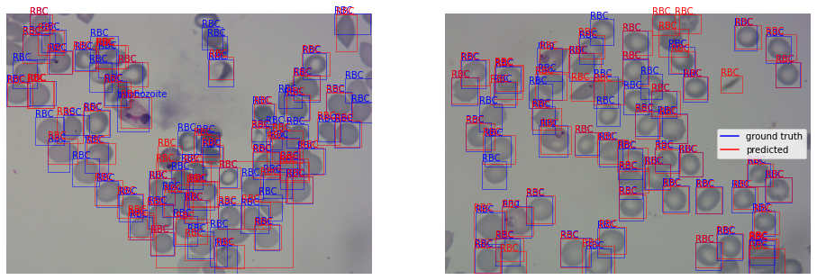

```python
fig, (ax1, ax2) = plt.subplots(nrows=1, ncols=2,figsize = (16,10))

cells1 = cells_image(number = 0, json_name = test, axis=ax1)
cells2 = cells_image(number = 1, json_name = test, axis=ax2)
id2label = {0: 'no_object', 1:'RBC', 2:'other'}

for c in [cells1,cells2]:
    scaled, cl = c.detect(test_dataset, model_epoch1)   # Predict bounding boxes and labels
    c.plot_cells()  # Plot blood smear images from test dataset
    c.plot_ground()  # Plot ground truth bounding boxes and class labels for each cell in blue
    c.plot_pred(scaled,cl,id2label)    # Plot predicted bounding boxes and class labels in red

legend_elements = [Line2D([0], [0], color='b'), Line2D([0], [0], color='r')]
ax2.legend(legend_elements,['ground truth','predicted'])
```

Whilst the model is able to detect most cells with good overlap (high GIoU), it struggles to detect cells in regions of the image where many cells are crowded together. In addition, for some cells, the model predicts multiple bounding boxes and, in the image on the left, it predicts a large bounding box that encompasses several cells. Together, this may explain, even though most cells are detected with high overlap, why the model has a low GIoU score. In addition, it must be noted that the ground truth bounding boxes were manually drawn and in many cases, the bounding boxes exclude edges of cells, miss cells near the borders of the image, encapsulate more than one cell or include too much of the background. Taking this into consideration, the error in the predicted bounding boxes for the majority of the cells may be considered acceptable.

Most importantly, due to limited computational resources, the model was only trained for two epochs on a relatively small dataset of 1000 images and training was stopped before the average training loss had converged. Training for a greater number of epochs until convergence would greatly improve the ability of the model to accurately detect between cells and distinguish between red blood cells and other cell types.

## Conclusion

In this study, I successfully fine-tuned a pre-trained DETR model, which uses a novel transformer architecture, to detect individual cells in a microscopy image of a blood smear. The model is able to detect most cells in a given image with very good overlap between the ground truth and predicted bounding boxes. Optimisation of this model will yield more accurate bounding boxes, especially in crowded regions, and better distinction between RBCs and other types of cells. In the second part of this notebook, I use a convolutional neural network (CNN) to perform more fine-grained classification and, subsequently, combine the fine-tuned DETR model with the CNN to completely automate the task of malaria diagnosis by microscopic examination.

## References

Carion, N. et al. (2020) ‘End-to-End Object Detection with Transformers’, Lecture Notes in Computer Science (including subseries Lecture Notes in Artificial Intelligence and Lecture Notes in Bioinformatics), 12346 LNCS, pp. 213–229.

CDC Diagnostic Procedures - Blood Specimens. Available at: https://www.cdc.gov/dpdx/diagnosticprocedures/blood/microexam.html

Explorer - Malaria Atlas Project. Available at: https://malariaatlas.org/explorer/#/ (Accessed: 12 September 2021).

Hung, J. et al. (2018) ‘Applying Faster R-CNN for Object Detection on Malaria Images’.

Makanjuola, R. O. and Taylor-Robinson, A. W. (2020) ‘Improving Accuracy of Malaria Diagnosis in Underserved Rural and Remote Endemic Areas of Sub-Saharan Africa: A Call to Develop Multiplexing Rapid Diagnostic Tests’, Scientifica, 2020.

Ogunfowokan, O., Ogunfowokan, B. A. and Nwajei, A. I. (2020) ‘Sensitivity and specificity of malaria rapid diagnostic test (mRDT CareStatTM) compared with microscopy amongst under five children attending a primary care clinic in southern Nigeria’, African Journal of Primary Health Care & Family Medicine, 12(1), pp. 1–8.

Rogge, N. (2020) Fine tuning Detr For Object Detection on custom dataset. Available at: https://github.com/NielsRogge/Transformers-Tutorials/blob/master/DETR

Rosenblatt, J. E., Reller, L. B. and Weinstein, M. P. (2009) ‘Laboratory Diagnosis of Infections Due to Blood and Tissue Parasites’, Clinical Infectious Diseases, 49(7), pp. 1103–1108.

Singh, T. (2020) End to End Object Detection with Transformers:DETR | Kaggle. Available at: https://www.kaggle.com/tanulsingh077/end-to-end-object-detection-with-transformers-detr

World Health Organisation World Malaria Report 2020. Available at: https://www.who.int/teams/global-malaria-programme/reports/world-malaria-report-2020

World Health Organization ‘Malaria surveillance , monitoring and evaluation: a reference manual’.

```python
from IPython.core.display import HTML
HTML("""
<style>
.output_png {
    display: table-cell;
    text-align: center;
    vertical-align: middle;
}
</style>
""")
```